# Assignment Report

## Task 3

Perform Random Forest, Decision tree, and pruned tree, and decision stamp, on the dataset from task2.

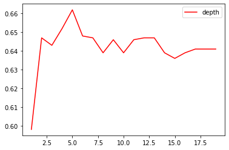

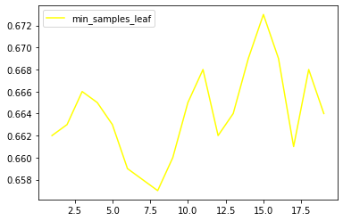

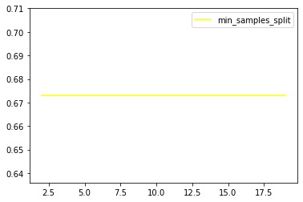

```
Best depth = 5, best min_samples_leaf = 15, best min_sample_split = 2


    Random Forest  Pruned Decision Tree  Unpruned Decision Tree  \
0           0.719                 0.672                   0.641
1           0.719                 0.672                   0.641
2           0.719                 0.673                   0.641
3           0.719                 0.674                   0.641
4           0.719                 0.673                   0.641
..            ...                   ...                     ...
95          0.719                 0.673                   0.641
96          0.719                 0.673                   0.641
97          0.719                 0.674                   0.641
98          0.719                 0.673                   0.641
99          0.719                 0.673                   0.641

    Decision Stamp
0            0.598
1            0.598
2            0.598
3            0.598
4            0.598
..             ...
95           0.598
96           0.598
97           0.598
98           0.598
99           0.598

[100 rows x 4 columns]
RankResult(rankdf=
                        meanrank  median  mad ci_lower ci_upper effect_size  \
Random Forest                1.0   0.719  0.0    0.719    0.719         NaN
Pruned Decision Tree         2.0   0.673  0.0    0.673    0.673         inf
Unpruned Decision Tree       3.0   0.641  0.0    0.641    0.641         inf
Decision Stamp               4.0   0.598  0.0    0.598    0.598         inf

                       magnitude
Random Forest              large
Pruned Decision Tree       large
```

[output cut: 12 more lines]

```
alpha_normality=0.0125
num_samples=100
posterior_matrix=
None
decision_matrix=
None
rope=None
rope_mode=None
effect_size=akinshin_gamma)
The statistical analysis was conducted for 4 populations with 100 paired samples.
The family-wise significance level of the tests is alpha=0.050.
We rejected the null hypothesis that the population is normal for the population Pruned Decision Tree (p=0.000). Therefore, we assume that not all populations are normal.
Because we have more than two populations and the populations and one of them is not normal, we use the non-parametric Friedman test as omnibus test to determine if there are any significant differences between the median values of the populations. We use the post-hoc Nemenyi test to infer which dif…
We reject the null hypothesis (p=0.000) of the Friedman test that there is no difference in the central tendency of the populations Random Forest (MD=0.719+-0.000, MAD=0.000, MR=1.000), Pruned Decision Tree (MD=0.673+-0.000, MAD=0.000, MR=2.000), Unpruned Decision Tree (MD=0.641+-0.000, MAD=0.000, M…
Based on the post-hoc Nemenyi test, we assume that all differences between the populations are significant.
```

```python
# As for pruning, in order to find out the best hyper parameters for pruning, we can use cross validation to test the score for each parameter
# tuning max_depth
res = []
bestScore = 0
best_max_depth = 0
for i in range(1,20):
    # Kfold = 5
    kfold = StratifiedKFold(n_splits=5, random_state=RANDOM_STATE, shuffle=True)
    score = []
    for idx_train, idx_test in kfold.split(X_Top10_Features, y):
        X_train = X_Top10_Features[idx_train]
        X_test = X_Top10_Features[idx_test]
        y_train = y[idx_train]
        y_test = y[idx_test]
        model = DecisionTreeClassifier(max_depth=i, random_state = RANDOM_STATE)
        model.fit(X_train, y_train)
        score.append(model.score(X_test, y_test))
    mean = np.mean(score)
    res.append(mean)
    if mean > bestScore:
        best_max_depth = i
        bestScore = mean

plt.plot(range(1,20), res, color = "red", label = "depth")
plt.legend()
plt.show()

# tuning min_samples_leaf
res = []
bestScore = 0
best_min_samples_leaf = 0
for i in range(1,20):
    # Kfold = 5
    kfold = StratifiedKFold(n_splits=5, random_state=RANDOM_STATE, shuffle=True)
    score = []
    for idx_train, idx_test in kfold.split(X_Top10_Features, y):
        X_train = X_Top10_Features[idx_train]
        X_test = X_Top10_Features[idx_test]
        y_train = y[idx_train]
        y_test = y[idx_test]
        model = DecisionTreeClassifier(max_depth=best_max_depth,min_samples_leaf=i, random_state = RANDOM_STATE)
        model.fit(X_train, y_train)
        score.append(model.score(X_test, y_test))
    mean = np.mean(score)
    res.append(mean)
    if mean > bestScore:
        best_min_samples_leaf = i
        bestScore = mean

plt.plot(range(1,20), res, color = "yellow", label = "min_samples_leaf")
plt.legend()
plt.show()

# tuning min_samples_split
res = []
bestScore = 0
best_min_samples_split = 0
for i in range(2,20):
    # Kfold = 5
    kfold = StratifiedKFold(n_splits=5, random_state=RANDOM_STATE, shuffle=True)
    score = []
    for idx_train, idx_test in kfold.split(X_Top10_Features, y):
        X_train = X_Top10_Features[idx_train]
        X_test = X_Top10_Features[idx_test]
        y_train = y[idx_train]
        y_test = y[idx_test]
        model = DecisionTreeClassifier(max_depth=best_max_depth,min_samples_leaf=best_min_samples_leaf, min_samples_split=i, random_state = RANDOM_STATE)
        model.fit(X_train, y_train)
        score.append(model.score(X_test, y_test))
    mean = np.mean(score)
    res.append(mean)
    if mean > bestScore:
        best_min_samples_split = i
        bestScore = mean

plt.plot(range(2,20), res, color = "yellow", label = "min_samples_split")
plt.legend()
plt.show()

print(f"Best depth = {best_max_depth}, best min_samples_leaf = {best_min_samples_leaf}, best min_sample_split = {best_min_samples_split}\n\n")
score_RF = []
score_PDT = []
score_DT = []
score_DS = []

for i in range(100):
    # step 1: k-fold
    kfold = StratifiedKFold(n_splits=5, random_state=RANDOM_STATE, shuffle=True)
    score1 = []
    score2 = []
    score3 = []
    score4 = []
    for idx_train, idx_test in kfold.split(X_Top10_Features, y):
        X_train = X_Top10_Features[idx_train]
        X_test = X_Top10_Features[idx_test]
        y_train = y[idx_train]
        y_test = y[idx_test]
        # step 2: Random Forest
        score1.append(RandomForestClassifier(n_estimators=20, random_state = RANDOM_STATE, n_jobs=-1).fit(X_train, y_train).score(X_test, y_test))

        # step 3: Pruned Decision Tree, pruning is on validation set

        score2.append(DecisionTreeClassifier(max_depth = best_max_depth, min_samples_leaf=best_min_samples_leaf, min_samples_split=best_min_samples_split).fit(X_train, y_train).score(X_test, y_test))

        # step 4: Unpruned Decision Tree
        score3.append(DecisionTreeClassifier(random_state=RANDOM_STATE).fit(X_train, y_train).score(X_test, y_test))

        # step 5: Dicision stamp
        score4.append(DecisionTreeClassifier(max_depth=1, random_state=RANDOM_STATE).fit(X_train, y_train).score(X_test, y_test))
    score_RF.append(np.mean(score1))
    score_PDT.append(np.mean(score2))
    score_DT.append(np.mean(score3))
    score_DS.append(np.mean(score4))
# step 6: Compare the models
df = pd.DataFrame()
df["Random Forest"] = score_RF
df["Pruned Decision Tree"] = score_PDT
df["Unpruned Decision Tree"] = score_DT
df["Decision Stamp"] = score_DS
print(df)
result = autorank(df,alpha=0.05, verbose=False)
print(result)
create_report(result)
plot_stats(result)
```

## Task 4

Apply 20% normal additive noise to the features. And then test the models.

```python
# step 1: add noise to the data
noise = np.random.normal(0, 0.2, np.shape(X_Top10_Features))
X_noise_add = X_Top10_Features + np.multiply(noise, np.average(X_Top10_Features, axis=0))
```

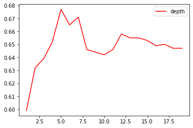

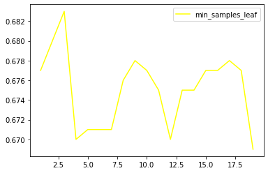

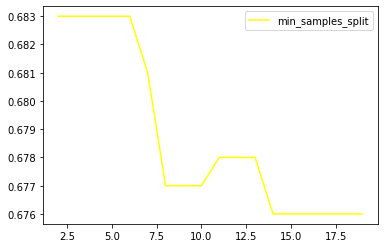

```
Best depth = 5, best min_samples_leaf = 3, best min_sample_split = 2


    Random Forest  Pruned Decision Tree  Unpruned Decision Tree  \
0           0.729                 0.677                   0.647
1           0.729                 0.677                   0.647
2           0.729                 0.674                   0.647
3           0.729                 0.680                   0.647
4           0.729                 0.678                   0.647
..            ...                   ...                     ...
95          0.729                 0.676                   0.647
96          0.729                 0.679                   0.647
97          0.729                 0.680                   0.647
98          0.729                 0.680                   0.647
99          0.729                 0.677                   0.647

    Decision Stamp
0            0.599
1            0.599
2            0.599
3            0.599
4            0.599
..             ...
95           0.599
96           0.599
97           0.599
98           0.599
99           0.599

[100 rows x 4 columns]
RankResult(rankdf=
                        meanrank     mean           std  ci_lower  ci_upper  \
Random Forest                1.0  0.72900  0.000000e+00     0.729     0.729
Pruned Decision Tree         2.0  0.67895  2.235503e-03  0.678381  0.679519
Unpruned Decision Tree       3.0  0.64700  1.115816e-16     0.647     0.647
Decision Stamp               4.0  0.59900  0.000000e+00     0.599     0.599

                                 effect_size magnitude
Random Forest                            NaN     large
Pruned Decision Tree               31.662396     large
```

[output cut: 13 more lines]

```
num_samples=100
posterior_matrix=
None
decision_matrix=
None
rope=None
rope_mode=None
effect_size=cohen_d)
The statistical analysis was conducted for 4 populations with 100 paired samples.
The family-wise significance level of the tests is alpha=0.050.
We failed to reject the null hypothesis that the population is normal for all populations (minimal observed p-value=0.049). Therefore, we assume that all populations are normal.
We applied Bartlett's test for homogeneity and reject the null hypothesis (p=0.000) that thedata is homoscedastic. Thus, we assume that our data is heteroscedastic.
Because we have more than two populations and the populations are normal but heteroscedastic, we use the non-parametric Friedman test as omnibus test to determine if there are any significant differences between the mean values of the populations. We use the post-hoc Nemenyi test to infer which diff…
We reject the null hypothesis (p=0.000) of the Friedman test that there is no difference in the central tendency of the populations Random Forest (M=0.729+-0.000, SD=0.000, MR=1.000), Pruned Decision Tree (M=0.679+-0.001, SD=0.002, MR=2.000), Unpruned Decision Tree (M=0.647+-0.000, SD=0.000, MR=3.00…
Based on the post-hoc Nemenyi test, we assume that all differences between the populations are significant.
```

```python
# As for pruning, in order to find out the best hyper parameters for pruning, we can use cross validation to test the score for each parameter
# tuning max_depth
res = []
bestScore = 0
best_max_depth = 0
for i in range(1,20):
    # Kfold = 5
    kfold = StratifiedKFold(n_splits=5, random_state=RANDOM_STATE, shuffle=True)
    score = []
    for idx_train, idx_test in kfold.split(X_noise_add, y):
        X_train = X_noise_add[idx_train]
        X_test = X_noise_add[idx_test]
        y_train = y[idx_train]
        y_test = y[idx_test]
        model = DecisionTreeClassifier(max_depth=i, random_state = RANDOM_STATE)
        model.fit(X_train, y_train)
        score.append(model.score(X_test, y_test))
    mean = np.mean(score)
    res.append(mean)
    if mean > bestScore:
        best_max_depth = i
        bestScore = mean

plt.plot(range(1,20), res, color = "red", label = "depth")
plt.legend()
plt.show()

# tuning min_samples_leaf
res = []
bestScore = 0
best_min_samples_leaf = 0
for i in range(1,20):
    # Kfold = 5
    kfold = StratifiedKFold(n_splits=5, random_state=RANDOM_STATE, shuffle=True)
    score = []
    for idx_train, idx_test in kfold.split(X_noise_add, y):
        X_train = X_noise_add[idx_train]
        X_test = X_noise_add[idx_test]
        y_train = y[idx_train]
        y_test = y[idx_test]
        model = DecisionTreeClassifier(max_depth=best_max_depth,min_samples_leaf=i, random_state = RANDOM_STATE)
        model.fit(X_train, y_train)
        score.append(model.score(X_test, y_test))
    mean = np.mean(score)
    res.append(mean)
    if mean > bestScore:
        best_min_samples_leaf = i
        bestScore = mean

plt.plot(range(1,20), res, color = "yellow", label = "min_samples_leaf")
plt.legend()
plt.show()

# tuning min_samples_split
res = []
bestScore = 0
best_min_samples_split = 0
for i in range(2,20):
    # Kfold = 5
    kfold = StratifiedKFold(n_splits=5, random_state=RANDOM_STATE, shuffle=True)
    score = []
    for idx_train, idx_test in kfold.split(X_noise_add, y):
        X_train = X_noise_add[idx_train]
        X_test = X_noise_add[idx_test]
        y_train = y[idx_train]
        y_test = y[idx_test]
        model = DecisionTreeClassifier(max_depth=best_max_depth,min_samples_leaf=best_min_samples_leaf, min_samples_split=i, random_state = RANDOM_STATE)
        model.fit(X_train, y_train)
        score.append(model.score(X_test, y_test))
    mean = np.mean(score)
    res.append(mean)
    if mean > bestScore:
        best_min_samples_split = i
        bestScore = mean

plt.plot(range(2,20), res, color = "yellow", label = "min_samples_split")
plt.legend()
plt.show()

print(f"Best depth = {best_max_depth}, best min_samples_leaf = {best_min_samples_leaf}, best min_sample_split = {best_min_samples_split}\n\n")
score_RF = []
score_PDT = []
score_DT = []
score_DS = []

for i in range(100):
    # step 1: k-fold
    kfold = StratifiedKFold(n_splits=5, random_state=RANDOM_STATE, shuffle=True)
    score1 = []
    score2 = []
    score3 = []
    score4 = []
    for idx_train, idx_test in kfold.split(X_noise_add, y):
        X_train = X_noise_add[idx_train]
        X_test = X_noise_add[idx_test]
        y_train = y[idx_train]
        y_test = y[idx_test]
        # step 2: Random Forest
        score1.append(RandomForestClassifier(n_estimators=20, random_state = RANDOM_STATE, n_jobs=-1).fit(X_train, y_train).score(X_test, y_test))

        # step 3: Pruned Decision Tree, pruning is on validation set

        score2.append(DecisionTreeClassifier(max_depth = best_max_depth, min_samples_leaf=best_min_samples_leaf, min_samples_split=best_min_samples_split).fit(X_train, y_train).score(X_test, y_test))

        # step 4: Unpruned Decision Tree
        score3.append(DecisionTreeClassifier(random_state=RANDOM_STATE).fit(X_train, y_train).score(X_test, y_test))

        # step 5: Dicision stamp
        score4.append(DecisionTreeClassifier(max_depth=1, random_state=RANDOM_STATE).fit(X_train, y_train).score(X_test, y_test))
    score_RF.append(np.mean(score1))
    score_PDT.append(np.mean(score2))
    score_DT.append(np.mean(score3))
    score_DS.append(np.mean(score4))
# step 6: Compare the models
df = pd.DataFrame()
df["Random Forest"] = score_RF
df["Pruned Decision Tree"] = score_PDT
df["Unpruned Decision Tree"] = score_DT
df["Decision Stamp"] = score_DS
print(df)
result = autorank(df,alpha=0.05, verbose=False)
print(result)
create_report(result)
plot_stats(result)
```

## Task 5

Add multiplicative normal noise to the features data. And perform the models.

```python
# step 1: miltply data matrix with noise matrix
noise = np.random.normal(1, 0.2, np.shape(X_Top10_Features))
X_noise_multiply = np.multiply(X_Top10_Features, noise)
X_noise_multiply
```

```
array([[-1.46554982, -2.33292012, -0.78147656, ...,  3.82438014,
         1.08856583, -0.22688057],
       [-0.85282247,  0.21059782,  1.19139395, ..., -1.62664186,
         0.37463427, -1.86884525],
       [ 0.55447186,  0.4321694 ,  3.49966096, ..., -4.42787138,
        -4.49780015, -4.33545658],
       ...,
       [-2.31872538,  0.30135213,  5.05603336, ...,  6.5590204 ,
         1.29719003, -4.65032234],
       [-2.09345627, -0.70998371, -3.32321748, ...,  2.1523191 ,
         0.16809829,  1.43497099],
       [-2.68719109, -2.33975399,  0.04771399, ...,  3.26512145,
        -0.47183405,  1.77378544]])
```

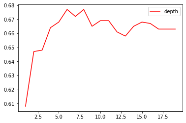

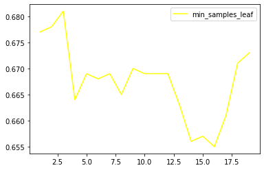

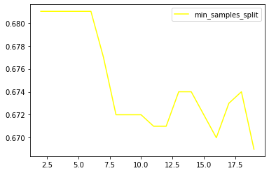

```
Best depth = 6, best min_samples_leaf = 3, best min_sample_split = 2


    Random Forest  Pruned Decision Tree  Unpruned Decision Tree  \
0           0.707                 0.678                   0.664
1           0.707                 0.677                   0.664
2           0.707                 0.682                   0.664
3           0.707                 0.683                   0.664
4           0.707                 0.682                   0.664
..            ...                   ...                     ...
95          0.707                 0.677                   0.664
96          0.707                 0.683                   0.664
97          0.707                 0.680                   0.664
98          0.707                 0.681                   0.664
99          0.707                 0.684                   0.664

    Decision Stamp
0            0.608
1            0.608
2            0.608
3            0.608
4            0.608
..             ...
95           0.608
96           0.608
97           0.608
98           0.608
99           0.608

[100 rows x 4 columns]
RankResult(rankdf=
                        meanrank     mean           std  ci_lower  ci_upper  \
Random Forest                1.0  0.70700  3.347448e-16     0.707     0.707
Pruned Decision Tree         2.0  0.67945  3.085892e-03  0.678665  0.680235
Unpruned Decision Tree       3.0  0.66400  1.115816e-16     0.664     0.664
Decision Stamp               4.0  0.60800  2.231632e-16     0.608     0.608

                                  effect_size   magnitude
Random Forest                             0.0  negligible
Pruned Decision Tree                12.625713       large
```

[output cut: 13 more lines]

```
num_samples=100
posterior_matrix=
None
decision_matrix=
None
rope=None
rope_mode=None
effect_size=cohen_d)
The statistical analysis was conducted for 4 populations with 100 paired samples.
The family-wise significance level of the tests is alpha=0.050.
We failed to reject the null hypothesis that the population is normal for all populations (minimal observed p-value=0.266). Therefore, we assume that all populations are normal.
We applied Bartlett's test for homogeneity and reject the null hypothesis (p=0.000) that thedata is homoscedastic. Thus, we assume that our data is heteroscedastic.
Because we have more than two populations and the populations are normal but heteroscedastic, we use the non-parametric Friedman test as omnibus test to determine if there are any significant differences between the mean values of the populations. We use the post-hoc Nemenyi test to infer which diff…
We reject the null hypothesis (p=0.000) of the Friedman test that there is no difference in the central tendency of the populations Random Forest (M=0.707+-0.000, SD=0.000, MR=1.000), Pruned Decision Tree (M=0.679+-0.001, SD=0.003, MR=2.000), Unpruned Decision Tree (M=0.664+-0.000, SD=0.000, MR=3.00…
Based on the post-hoc Nemenyi test, we assume that all differences between the populations are significant.
```

```python
# As for pruning, in order to find out the best hyper parameters for pruning, we can use cross validation to test the score for each parameter
# tuning max_depth
res = []
bestScore = 0
best_max_depth = 0
for i in range(1,20):
    # Kfold = 5
    kfold = StratifiedKFold(n_splits=5, random_state=RANDOM_STATE, shuffle=True)
    score = []
    for idx_train, idx_test in kfold.split(X_noise_multiply, y):
        X_train = X_noise_multiply[idx_train]
        X_test = X_noise_multiply[idx_test]
        y_train = y[idx_train]
        y_test = y[idx_test]
        model = DecisionTreeClassifier(max_depth=i, random_state = RANDOM_STATE)
        model.fit(X_train, y_train)
        score.append(model.score(X_test, y_test))
    mean = np.mean(score)
    res.append(mean)
    if mean > bestScore:
        best_max_depth = i
        bestScore = mean

plt.plot(range(1,20), res, color = "red", label = "depth")
plt.legend()
plt.show()

# tuning min_samples_leaf
res = []
bestScore = 0
best_min_samples_leaf = 0
for i in range(1,20):
    # Kfold = 5
    kfold = StratifiedKFold(n_splits=5, random_state=RANDOM_STATE, shuffle=True)
    score = []
    for idx_train, idx_test in kfold.split(X_noise_multiply, y):
        X_train = X_noise_multiply[idx_train]
        X_test = X_noise_multiply[idx_test]
        y_train = y[idx_train]
        y_test = y[idx_test]
        model = DecisionTreeClassifier(max_depth=best_max_depth,min_samples_leaf=i, random_state = RANDOM_STATE)
        model.fit(X_train, y_train)
        score.append(model.score(X_test, y_test))
    mean = np.mean(score)
    res.append(mean)
    if mean > bestScore:
        best_min_samples_leaf = i
        bestScore = mean

plt.plot(range(1,20), res, color = "yellow", label = "min_samples_leaf")
plt.legend()
plt.show()

# tuning min_samples_split
res = []
bestScore = 0
best_min_samples_split = 0
for i in range(2,20):
    # Kfold = 5
    kfold = StratifiedKFold(n_splits=5, random_state=RANDOM_STATE, shuffle=True)
    score = []
    for idx_train, idx_test in kfold.split(X_noise_multiply, y):
        X_train = X_noise_multiply[idx_train]
        X_test = X_noise_multiply[idx_test]
        y_train = y[idx_train]
        y_test = y[idx_test]
        model = DecisionTreeClassifier(max_depth=best_max_depth,min_samples_leaf=best_min_samples_leaf, min_samples_split=i, random_state = RANDOM_STATE)
        model.fit(X_train, y_train)
        score.append(model.score(X_test, y_test))
    mean = np.mean(score)
    res.append(mean)
    if mean > bestScore:
        best_min_samples_split = i
        bestScore = mean

plt.plot(range(2,20), res, color = "yellow", label = "min_samples_split")
plt.legend()
plt.show()

print(f"Best depth = {best_max_depth}, best min_samples_leaf = {best_min_samples_leaf}, best min_sample_split = {best_min_samples_split}\n\n")
score_RF = []
score_PDT = []
score_DT = []
score_DS = []

for i in range(100):
    # step 1: k-fold
    kfold = StratifiedKFold(n_splits=5, random_state=RANDOM_STATE, shuffle=True)
    score1 = []
    score2 = []
    score3 = []
    score4 = []
    for idx_train, idx_test in kfold.split(X_noise_multiply, y):
        X_train = X_noise_multiply[idx_train]
        X_test = X_noise_multiply[idx_test]
        y_train = y[idx_train]
        y_test = y[idx_test]
        # step 2: Random Forest
        score1.append(RandomForestClassifier(n_estimators=20, random_state = RANDOM_STATE, n_jobs=-1).fit(X_train, y_train).score(X_test, y_test))

        # step 3: Pruned Decision Tree, pruning is on validation set

        score2.append(DecisionTreeClassifier(max_depth = best_max_depth, min_samples_leaf=best_min_samples_leaf, min_samples_split=best_min_samples_split).fit(X_train, y_train).score(X_test, y_test))

        # step 4: Unpruned Decision Tree
        score3.append(DecisionTreeClassifier(random_state=RANDOM_STATE).fit(X_train, y_train).score(X_test, y_test))

        # step 5: Dicision stamp
        score4.append(DecisionTreeClassifier(max_depth=1, random_state=RANDOM_STATE).fit(X_train, y_train).score(X_test, y_test))
    score_RF.append(np.mean(score1))
    score_PDT.append(np.mean(score2))
    score_DT.append(np.mean(score3))
    score_DS.append(np.mean(score4))
# step 6: Compare the models
df = pd.DataFrame()
df["Random Forest"] = score_RF
df["Pruned Decision Tree"] = score_PDT
df["Unpruned Decision Tree"] = score_DT
df["Decision Stamp"] = score_DS
print(df)
result = autorank(df,alpha=0.05, verbose=False)
print(result)
create_report(result)
plot_stats(result)
```

## Task 6

Apply 5% class noise to the label data.

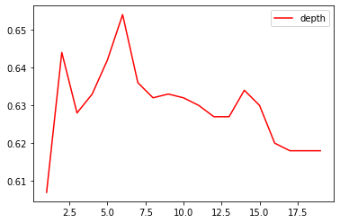

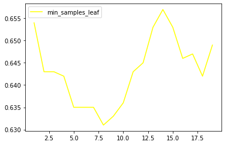

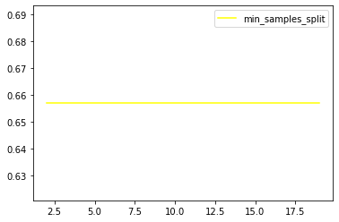

```
Best depth = 6, best min_samples_leaf = 14, best min_sample_split = 2


    Random Forest  Pruned Decision Tree  Unpruned Decision Tree  \
0           0.695                 0.654                   0.618
1           0.695                 0.654                   0.618
2           0.695                 0.657                   0.618
3           0.695                 0.657                   0.618
4           0.695                 0.657                   0.618
..            ...                   ...                     ...
95          0.695                 0.657                   0.618
96          0.695                 0.654                   0.618
97          0.695                 0.657                   0.618
98          0.695                 0.657                   0.618
99          0.695                 0.657                   0.618

    Decision Stamp
0            0.607
1            0.607
2            0.607
3            0.607
4            0.607
..             ...
95           0.607
96           0.607
97           0.607
98           0.607
99           0.607

[100 rows x 4 columns]
RankResult(rankdf=
                        meanrank  median  mad ci_lower ci_upper effect_size  \
Random Forest                1.0   0.695  0.0    0.695    0.695         NaN
Pruned Decision Tree         2.0   0.657  0.0    0.654    0.657         inf
Unpruned Decision Tree       3.0   0.618  0.0    0.618    0.618         inf
Decision Stamp               4.0   0.607  0.0    0.607    0.607         inf

                       magnitude
Random Forest              large
Pruned Decision Tree       large
```

[output cut: 12 more lines]

```
alpha_normality=0.0125
num_samples=100
posterior_matrix=
None
decision_matrix=
None
rope=None
rope_mode=None
effect_size=akinshin_gamma)
The statistical analysis was conducted for 4 populations with 100 paired samples.
The family-wise significance level of the tests is alpha=0.050.
We rejected the null hypothesis that the population is normal for the population Pruned Decision Tree (p=0.000). Therefore, we assume that not all populations are normal.
Because we have more than two populations and the populations and one of them is not normal, we use the non-parametric Friedman test as omnibus test to determine if there are any significant differences between the median values of the populations. We use the post-hoc Nemenyi test to infer which dif…
We reject the null hypothesis (p=0.000) of the Friedman test that there is no difference in the central tendency of the populations Random Forest (MD=0.695+-0.000, MAD=0.000, MR=1.000), Pruned Decision Tree (MD=0.657+-0.001, MAD=0.000, MR=2.000), Unpruned Decision Tree (MD=0.618+-0.000, MAD=0.000, M…
Based on the post-hoc Nemenyi test, we assume that all differences between the populations are significant.
```

```python
# step 1: flip 5% of the labels randomly
import random
y_np = y
for i in range(len(y_np)):
    getChoice = random.random()
    if getChoice < 0.05:
#         print(f"Flip index: {i}")
        y_np[i] = 1 - y_np[i]

# As for pruning, in order to find out the best hyper parameters for pruning, we can use cross validation to test the score for each parameter
# tuning max_depth
res = []
bestScore = 0
best_max_depth = 0
for i in range(1,20):
    # Kfold = 5
    kfold = StratifiedKFold(n_splits=5, random_state=RANDOM_STATE, shuffle=True)
    score = []
    for idx_train, idx_test in kfold.split(X_Top10_Features, y_np):
        X_train = X_Top10_Features[idx_train]
        X_test = X_Top10_Features[idx_test]
        y_train = y_np[idx_train]
        y_test = y_np[idx_test]
        model = DecisionTreeClassifier(max_depth=i, random_state = RANDOM_STATE)
        model.fit(X_train, y_train)
        score.append(model.score(X_test, y_test))
    mean = np.mean(score)
    res.append(mean)
    if mean > bestScore:
        best_max_depth = i
        bestScore = mean

plt.plot(range(1,20), res, color = "red", label = "depth")
plt.legend()
plt.show()

# tuning min_samples_leaf
res = []
bestScore = 0
best_min_samples_leaf = 0
for i in range(1,20):
    # Kfold = 5
    kfold = StratifiedKFold(n_splits=5, random_state=RANDOM_STATE, shuffle=True)
    score = []
    for idx_train, idx_test in kfold.split(X_Top10_Features, y_np):
        X_train = X_Top10_Features[idx_train]
        X_test = X_Top10_Features[idx_test]
        y_train = y_np[idx_train]
        y_test = y_np[idx_test]
        model = DecisionTreeClassifier(max_depth=best_max_depth,min_samples_leaf=i, random_state = RANDOM_STATE)
        model.fit(X_train, y_train)
        score.append(model.score(X_test, y_test))
    mean = np.mean(score)
    res.append(mean)
    if mean > bestScore:
        best_min_samples_leaf = i
        bestScore = mean

plt.plot(range(1,20), res, color = "yellow", label = "min_samples_leaf")
plt.legend()
plt.show()

# tuning min_samples_split
res = []
bestScore = 0
best_min_samples_split = 0
for i in range(2,20):
    # Kfold = 5
    kfold = StratifiedKFold(n_splits=5, random_state=RANDOM_STATE, shuffle=True)
    score = []
    for idx_train, idx_test in kfold.split(X_Top10_Features, y_np):
        X_train = X_Top10_Features[idx_train]
        X_test = X_Top10_Features[idx_test]
        y_train = y_np[idx_train]
        y_test = y_np[idx_test]
        model = DecisionTreeClassifier(max_depth=best_max_depth,min_samples_leaf=best_min_samples_leaf, min_samples_split=i, random_state = RANDOM_STATE)
        model.fit(X_train, y_train)
        score.append(model.score(X_test, y_test))
    mean = np.mean(score)
    res.append(mean)
    if mean > bestScore:
        best_min_samples_split = i
        bestScore = mean

plt.plot(range(2,20), res, color = "yellow", label = "min_samples_split")
plt.legend()
plt.show()

print(f"Best depth = {best_max_depth}, best min_samples_leaf = {best_min_samples_leaf}, best min_sample_split = {best_min_samples_split}\n\n")
score_RF = []
score_PDT = []
score_DT = []
score_DS = []

for i in range(100):
    # step 1: k-fold
    kfold = StratifiedKFold(n_splits=5, random_state=RANDOM_STATE, shuffle=True)
    score1 = []
    score2 = []
    score3 = []
    score4 = []
    for idx_train, idx_test in kfold.split(X_Top10_Features, y_np):
        X_train = X_Top10_Features[idx_train]
        X_test = X_Top10_Features[idx_test]
        y_train = y_np[idx_train]
        y_test = y_np[idx_test]
        # step 2: Random Forest
        score1.append(RandomForestClassifier(n_estimators=20, random_state = RANDOM_STATE, n_jobs=-1).fit(X_train, y_train).score(X_test, y_test))

        # step 3: Pruned Decision Tree, pruning is on validation set

        score2.append(DecisionTreeClassifier(max_depth = best_max_depth, min_samples_leaf=best_min_samples_leaf, min_samples_split=best_min_samples_split).fit(X_train, y_train).score(X_test, y_test))

        # step 4: Unpruned Decision Tree
        score3.append(DecisionTreeClassifier(random_state=RANDOM_STATE).fit(X_train, y_train).score(X_test, y_test))

        # step 5: Dicision stamp
        score4.append(DecisionTreeClassifier(max_depth=1, random_state=RANDOM_STATE).fit(X_train, y_train).score(X_test, y_test))
    score_RF.append(np.mean(score1))
    score_PDT.append(np.mean(score2))
    score_DT.append(np.mean(score3))
    score_DS.append(np.mean(score4))
# step 6: Compare the models
df = pd.DataFrame()
df["Random Forest"] = score_RF
df["Pruned Decision Tree"] = score_PDT
df["Unpruned Decision Tree"] = score_DT
df["Decision Stamp"] = score_DS
print(df)
result = autorank(df,alpha=0.05, verbose=False)
print(result)
create_report(result)
plot_stats(result)
```

## Task 7

Split the data first and then multiply 20% noise to the training set. Then compare the models.

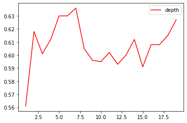

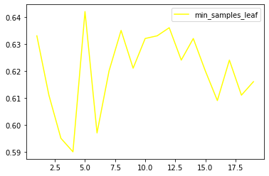

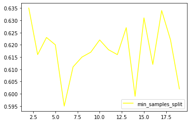

```
Best depth = 7, best min_samples_leaf = 5, best min_sample_split = 2


    Random Forest  Pruned Decision Tree  Unpruned Decision Tree  \
0           0.661                 0.595                   0.596
1           0.659                 0.630                   0.608
2           0.667                 0.598                   0.608
3           0.666                 0.623                   0.607
4           0.645                 0.640                   0.613
..            ...                   ...                     ...
95          0.657                 0.591                   0.606
96          0.659                 0.607                   0.600
97          0.657                 0.623                   0.608
98          0.669                 0.602                   0.598
99          0.660                 0.617                   0.603

    Decision Stamp
0            0.567
1            0.558
2            0.546
3            0.564
4            0.559
..             ...
95           0.558
96           0.577
97           0.550
98           0.565
99           0.556

[100 rows x 4 columns]
RankResult(rankdf=
                        meanrank     mean       std  ci_lower  ci_upper  \
Random Forest               1.01  0.65947  0.009477  0.657059  0.661881
Pruned Decision Tree        2.27  0.61059  0.014225  0.606971  0.614209
Unpruned Decision Tree      2.72  0.60181  0.013863  0.598283  0.605337
Decision Stamp              4.00  0.56221  0.008599  0.560022  0.564398

                       effect_size   magnitude
Random Forest                  0.0  negligible
Pruned Decision Tree      4.044281       large
```

[output cut: 13 more lines]

```
num_samples=100
posterior_matrix=
None
decision_matrix=
None
rope=None
rope_mode=None
effect_size=cohen_d)
The statistical analysis was conducted for 4 populations with 100 paired samples.
The family-wise significance level of the tests is alpha=0.050.
We failed to reject the null hypothesis that the population is normal for all populations (minimal observed p-value=0.436). Therefore, we assume that all populations are normal.
We applied Bartlett's test for homogeneity and reject the null hypothesis (p=0.000) that thedata is homoscedastic. Thus, we assume that our data is heteroscedastic.
Because we have more than two populations and the populations are normal but heteroscedastic, we use the non-parametric Friedman test as omnibus test to determine if there are any significant differences between the mean values of the populations. We use the post-hoc Nemenyi test to infer which diff…
We reject the null hypothesis (p=0.000) of the Friedman test that there is no difference in the central tendency of the populations Random Forest (M=0.659+-0.002, SD=0.009, MR=1.010), Pruned Decision Tree (M=0.611+-0.004, SD=0.014, MR=2.270), Unpruned Decision Tree (M=0.602+-0.004, SD=0.014, MR=2.72…
Based on the post-hoc Nemenyi test, we assume that there are no significant differences within the following groups: Pruned Decision Tree and Unpruned Decision Tree. All other differences are significant.
```

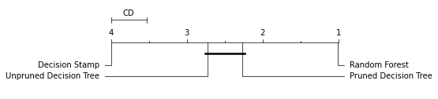

```python
# As for pruning, in order to find out the best hyper parameters for pruning, we can use cross validation to test the score for each parameter
# tuning max_depth
res = []
bestScore = 0
best_max_depth = 0
for i in range(1,20):
    # Kfold = 5
    kfold = StratifiedKFold(n_splits=5, random_state=RANDOM_STATE, shuffle=True)
    score = []
    for idx_train, idx_test in kfold.split(X_Top10_Features, y):
        X_train = X_Top10_Features[idx_train]
        X_test = X_Top10_Features[idx_test]
        y_train = y[idx_train]
        y_test = y[idx_test]
        # Add noise here
        noise = np.random.normal(1, 0.2, np.shape(X_train))
        X_train_noise = X_train + np.multiply(X_train, noise)
        model = DecisionTreeClassifier(max_depth=i, random_state = RANDOM_STATE)
        model.fit(X_train_noise, y_train)
        score.append(model.score(X_test, y_test))
    mean = np.mean(score)
    res.append(mean)
    if mean > bestScore:
        best_max_depth = i
        bestScore = mean

plt.plot(range(1,20), res, color = "red", label = "depth")
plt.legend()
plt.show()

# tuning min_samples_leaf
res = []
bestScore = 0
best_min_samples_leaf = 0
for i in range(1,20):
    # Kfold = 5
    kfold = StratifiedKFold(n_splits=5, random_state=RANDOM_STATE, shuffle=True)
    score = []
    for idx_train, idx_test in kfold.split(X_Top10_Features, y):
        X_train = X_Top10_Features[idx_train]
        X_test = X_Top10_Features[idx_test]
        y_train = y[idx_train]
        y_test = y[idx_test]
        # Add noise here
        noise = np.random.normal(1, 0.2, np.shape(X_train))
        X_train_noise = X_train + np.multiply(X_train, noise)

        model = DecisionTreeClassifier(max_depth=best_max_depth,min_samples_leaf=i, random_state = RANDOM_STATE)
        model.fit(X_train_noise, y_train)
        score.append(model.score(X_test, y_test))
    mean = np.mean(score)
    res.append(mean)
    if mean > bestScore:
        best_min_samples_leaf = i
        bestScore = mean

plt.plot(range(1,20), res, color = "yellow", label = "min_samples_leaf")
plt.legend()
plt.show()

# tuning min_samples_split
res = []
bestScore = 0
best_min_samples_split = 0
for i in range(2,20):
    # Kfold = 5
    kfold = StratifiedKFold(n_splits=5, random_state=RANDOM_STATE, shuffle=True)
    score = []
    for idx_train, idx_test in kfold.split(X_Top10_Features, y):
        X_train = X_Top10_Features[idx_train]
        X_test = X_Top10_Features[idx_test]
        y_train = y[idx_train]
        y_test = y[idx_test]
        # Add noise here
        noise = np.random.normal(1, 0.2, np.shape(X_train))
        X_train_noise = X_train + np.multiply(X_train, noise)

        model = DecisionTreeClassifier(max_depth=best_max_depth,min_samples_leaf=best_min_samples_leaf, min_samples_split=i, random_state = RANDOM_STATE)
        model.fit(X_train_noise, y_train)
        score.append(model.score(X_test, y_test))
    mean = np.mean(score)
    res.append(mean)
    if mean > bestScore:
        best_min_samples_split = i
        bestScore = mean

plt.plot(range(2,20), res, color = "yellow", label = "min_samples_split")
plt.legend()
plt.show()

print(f"Best depth = {best_max_depth}, best min_samples_leaf = {best_min_samples_leaf}, best min_sample_split = {best_min_samples_split}\n\n")
score_RF = []
score_PDT = []
score_DT = []
score_DS = []

for i in range(100):
    # step 1: k-fold
    kfold = StratifiedKFold(n_splits=5, random_state=RANDOM_STATE, shuffle=True)
    score1 = []
    score2 = []
    score3 = []
    score4 = []
    for idx_train, idx_test in kfold.split(X_Top10_Features, y):
        X_train = X_Top10_Features[idx_train]
        X_test = X_Top10_Features[idx_test]
        y_train = y[idx_train]
        y_test = y[idx_test]
        # Add noise here
        noise = np.random.normal(1, 0.2, np.shape(X_train))
        X_train_noise = X_train + np.multiply(X_train, noise)

        # step 2: Random Forest
        score1.append(RandomForestClassifier(n_estimators=20, random_state = RANDOM_STATE, n_jobs=-1).fit(X_train_noise, y_train).score(X_test, y_test))

        # step 3: Pruned Decision Tree, pruning is on validation set

        score2.append(DecisionTreeClassifier(max_depth = best_max_depth, min_samples_leaf=best_min_samples_leaf, min_samples_split=best_min_samples_split).fit(X_train_noise, y_train).score(X_test, y_test))

        # step 4: Unpruned Decision Tree
        score3.append(DecisionTreeClassifier(random_state=RANDOM_STATE).fit(X_train_noise, y_train).score(X_test, y_test))

        # step 5: Dicision stamp
        score4.append(DecisionTreeClassifier(max_depth=1, random_state=RANDOM_STATE).fit(X_train_noise, y_train).score(X_test, y_test))
    score_RF.append(np.mean(score1))
    score_PDT.append(np.mean(score2))
    score_DT.append(np.mean(score3))
    score_DS.append(np.mean(score4))
# step 6: Compare the models
df = pd.DataFrame()
df["Random Forest"] = score_RF
df["Pruned Decision Tree"] = score_PDT
df["Unpruned Decision Tree"] = score_DT
df["Decision Stamp"] = score_DS
print(df)
result = autorank(df,alpha=0.05, verbose=False)
print(result)
create_report(result)
plot_stats(result)
```

Add noise to test set

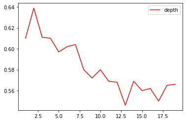

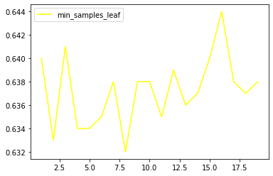

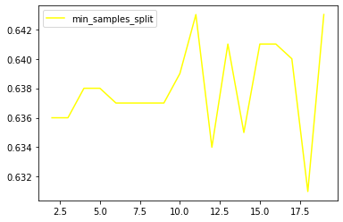

```
Best depth = 2, best min_samples_leaf = 16, best min_sample_split = 11


    Random Forest  Pruned Decision Tree  Unpruned Decision Tree  \
0           0.645                 0.640                   0.559
1           0.658                 0.635                   0.557
2           0.664                 0.640                   0.559
3           0.646                 0.638                   0.564
4           0.649                 0.642                   0.565
..            ...                   ...                     ...
95          0.653                 0.636                   0.551
96          0.651                 0.639                   0.556
97          0.644                 0.639                   0.570
98          0.643                 0.638                   0.562
99          0.643                 0.636                   0.571

    Decision Stamp
0            0.609
1            0.604
2            0.609
3            0.612
4            0.611
..             ...
95           0.607
96           0.612
97           0.610
98           0.609
99           0.608

[100 rows x 4 columns]
RankResult(rankdf=
                        meanrank  median       mad ci_lower ci_upper  \
Random Forest               1.07   0.650  0.008896    0.647    0.657
Pruned Decision Tree        1.93   0.639  0.002965    0.637     0.64
Decision Stamp              3.00   0.610  0.001483    0.609    0.611
Unpruned Decision Tree      4.00   0.563  0.007413    0.559    0.566

                       effect_size   magnitude
Random Forest                  0.0  negligible
Pruned Decision Tree      1.659028       large
```

[output cut: 12 more lines]

```
alpha_normality=0.0125
num_samples=100
posterior_matrix=
None
decision_matrix=
None
rope=None
rope_mode=None
effect_size=akinshin_gamma)
The statistical analysis was conducted for 4 populations with 100 paired samples.
The family-wise significance level of the tests is alpha=0.050.
We rejected the null hypothesis that the population is normal for the population Unpruned Decision Tree (p=0.007). Therefore, we assume that not all populations are normal.
Because we have more than two populations and the populations and one of them is not normal, we use the non-parametric Friedman test as omnibus test to determine if there are any significant differences between the median values of the populations. We use the post-hoc Nemenyi test to infer which dif…
We reject the null hypothesis (p=0.000) of the Friedman test that there is no difference in the central tendency of the populations Random Forest (MD=0.650+-0.005, MAD=0.009, MR=1.070), Pruned Decision Tree (MD=0.639+-0.002, MAD=0.003, MR=1.930), Decision Stamp (MD=0.610+-0.001, MAD=0.001, MR=3.000)…
Based on the post-hoc Nemenyi test, we assume that all differences between the populations are significant.
```

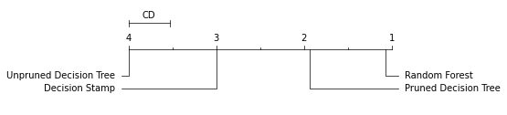

```python
# As for pruning, in order to find out the best hyper parameters for pruning, we can use cross validation to test the score for each parameter
# tuning max_depth
res = []
bestScore = 0
best_max_depth = 0
for i in range(1,20):
    # Kfold = 5
    kfold = StratifiedKFold(n_splits=5, random_state=RANDOM_STATE, shuffle=True)
    score = []
    for idx_train, idx_test in kfold.split(X_Top10_Features, y):
        X_train = X_Top10_Features[idx_train]
        X_test = X_Top10_Features[idx_test]
        y_train = y[idx_train]
        y_test = y[idx_test]
        # Add noise here
        noise = np.random.normal(1, 0.2, np.shape(X_test))
        X_test_noise = X_test + np.multiply(X_test, noise)
        model = DecisionTreeClassifier(max_depth=i, random_state = RANDOM_STATE)
        model.fit(X_train, y_train)
        score.append(model.score(X_test_noise, y_test))
    mean = np.mean(score)
    res.append(mean)
    if mean > bestScore:
        best_max_depth = i
        bestScore = mean

plt.plot(range(1,20), res, color = "red", label = "depth")
plt.legend()
plt.show()

# tuning min_samples_leaf
res = []
bestScore = 0
best_min_samples_leaf = 0
for i in range(1,20):
    # Kfold = 5
    kfold = StratifiedKFold(n_splits=5, random_state=RANDOM_STATE, shuffle=True)
    score = []
    for idx_train, idx_test in kfold.split(X_Top10_Features, y):
        X_train = X_Top10_Features[idx_train]
        X_test = X_Top10_Features[idx_test]
        y_train = y[idx_train]
        y_test = y[idx_test]
        # Add noise here
        noise = np.random.normal(1, 0.2, np.shape(X_test))
        X_test_noise = X_test + np.multiply(X_test, noise)
        model = DecisionTreeClassifier(max_depth=best_max_depth,min_samples_leaf=i, random_state = RANDOM_STATE)
        model.fit(X_train, y_train)
        score.append(model.score(X_test_noise, y_test))
    mean = np.mean(score)
    res.append(mean)
    if mean > bestScore:
        best_min_samples_leaf = i
        bestScore = mean

plt.plot(range(1,20), res, color = "yellow", label = "min_samples_leaf")
plt.legend()
plt.show()

# tuning min_samples_split
res = []
bestScore = 0
best_min_samples_split = 0
for i in range(2,20):
    # Kfold = 5
    kfold = StratifiedKFold(n_splits=5, random_state=RANDOM_STATE, shuffle=True)
    score = []
    for idx_train, idx_test in kfold.split(X_Top10_Features, y):
        X_train = X_Top10_Features[idx_train]
        X_test = X_Top10_Features[idx_test]
        y_train = y[idx_train]
        y_test = y[idx_test]
        # Add noise here
        noise = np.random.normal(1, 0.2, np.shape(X_test))
        X_test_noise = X_test + np.multiply(X_test, noise)

        model = DecisionTreeClassifier(max_depth=best_max_depth,min_samples_leaf=best_min_samples_leaf, min_samples_split=i, random_state = RANDOM_STATE)
        model.fit(X_train, y_train)
        score.append(model.score(X_test_noise, y_test))
    mean = np.mean(score)
    res.append(mean)
    if mean > bestScore:
        best_min_samples_split = i
        bestScore = mean

plt.plot(range(2,20), res, color = "yellow", label = "min_samples_split")
plt.legend()
plt.show()

print(f"Best depth = {best_max_depth}, best min_samples_leaf = {best_min_samples_leaf}, best min_sample_split = {best_min_samples_split}\n\n")
score_RF = []
score_PDT = []
score_DT = []
score_DS = []

for i in range(100):
    # step 1: k-fold
    kfold = StratifiedKFold(n_splits=5, random_state=RANDOM_STATE, shuffle=True)
    score1 = []
    score2 = []
    score3 = []
    score4 = []
    for idx_train, idx_test in kfold.split(X_Top10_Features, y):
        X_train = X_Top10_Features[idx_train]
        X_test = X_Top10_Features[idx_test]
        y_train = y[idx_train]
        y_test = y[idx_test]
        # Add noise here
        noise = np.random.normal(1, 0.2, np.shape(X_test))
        X_test_noise = X_test + np.multiply(X_test, noise)
        # step 2: Random Forest
        score1.append(RandomForestClassifier(n_estimators=20, random_state = RANDOM_STATE, n_jobs=-1).fit(X_train, y_train).score(X_test_noise, y_test))

        # step 3: Pruned Decision Tree, pruning is on validation set

        score2.append(DecisionTreeClassifier(max_depth = best_max_depth, min_samples_leaf=best_min_samples_leaf, min_samples_split=best_min_samples_split).fit(X_train, y_train).score(X_test_noise, y_test))

        # step 4: Unpruned Decision Tree
        score3.append(DecisionTreeClassifier(random_state=RANDOM_STATE).fit(X_train, y_train).score(X_test_noise, y_test))

        # step 5: Dicision stamp
        score4.append(DecisionTreeClassifier(max_depth=1, random_state=RANDOM_STATE).fit(X_train, y_train).score(X_test_noise, y_test))
    score_RF.append(np.mean(score1))
    score_PDT.append(np.mean(score2))
    score_DT.append(np.mean(score3))
    score_DS.append(np.mean(score4))
# step 6: Compare the models
df = pd.DataFrame()
df["Random Forest"] = score_RF
df["Pruned Decision Tree"] = score_PDT
df["Unpruned Decision Tree"] = score_DT
df["Decision Stamp"] = score_DS
print(df)
result = autorank(df,alpha=0.05, verbose=False)
print(result)
create_report(result)
plot_stats(result)
```

## Task Bonus

Identify how higher the noise is that will break the models.

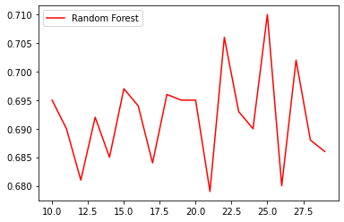

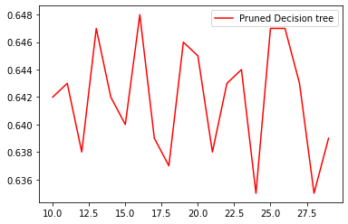

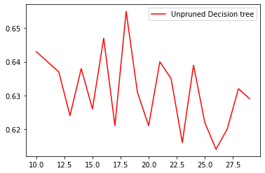

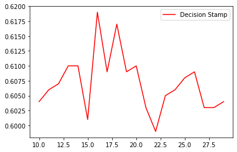

```python
# noise added to features, at 20% all works fine, so we add percentage of noise
res1 = []
res2 = []
res3 = []
res4 = []
interval = (10, 30, 1)
for i in range(*interval):
    # add noise
    noise = np.random.normal(0, i/100.0, np.shape(X_Top10_Features))
    X_noise_add = X_Top10_Features + np.multiply(noise, np.average(X_Top10_Features, axis=0))

    kfold = StratifiedKFold(n_splits=5, random_state=RANDOM_STATE, shuffle=True)
    score1 = []
    score2 = []
    score3 = []
    score4 = []
    for idx_train, idx_test in kfold.split(X_noise_add, y):
        X_train = X_noise_add[idx_train]
        X_test = X_noise_add[idx_test]
        y_train = y[idx_train]
        y_test = y[idx_test]
        # step 2: Random Forest
        score1.append(RandomForestClassifier(n_estimators=20, random_state = RANDOM_STATE, n_jobs=-1).fit(X_train, y_train).score(X_test, y_test))

        # step 3: Pruned Decision Tree, pruning is on validation set

        score2.append(DecisionTreeClassifier(max_depth = best_max_depth, min_samples_leaf=best_min_samples_leaf, min_samples_split=best_min_samples_split).fit(X_train, y_train).score(X_test, y_test))

        # step 4: Unpruned Decision Tree
        score3.append(DecisionTreeClassifier(random_state=RANDOM_STATE).fit(X_train, y_train).score(X_test, y_test))

        # step 5: Dicision stamp
        score4.append(DecisionTreeClassifier(max_depth=1, random_state=RANDOM_STATE).fit(X_train, y_train).score(X_test, y_test))
    res1.append(np.mean(score1))
    res2.append(np.mean(score2))
    res3.append(np.mean(score3))
    res4.append(np.mean(score4))


plt.plot(range(*interval), res1, color = "red", label = "Random Forest")
plt.legend()
plt.show()

plt.plot(range(*interval), res2, color = "red", label = "Pruned Decision tree")
plt.legend()
plt.show()

plt.plot(range(*interval), res3, color = "red", label = "Unpruned Decision tree")
plt.legend()
plt.show()

plt.plot(range(*interval), res4, color = "red", label = "Decision Stamp")
plt.legend()
plt.show()
```

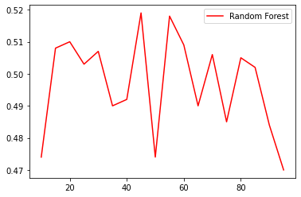

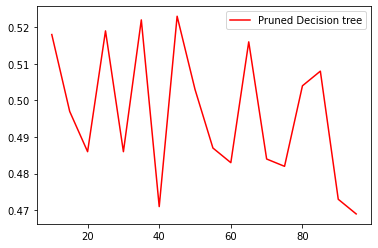

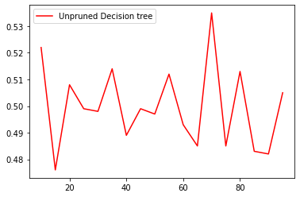

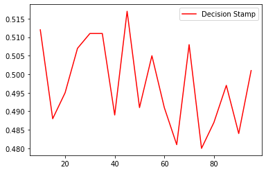

```python
# noise multiplied to features
res1 = []
res2 = []
res3 = []
res4 = []
interval = (10, 100, 5)
for i in range(*interval):
    noise = np.random.normal(0, i/100.0, np.shape(X_Top10_Features))
    X_noise_multiply = np.multiply(noise, np.average(X_Top10_Features, axis=0))

    kfold = StratifiedKFold(n_splits=5, random_state=RANDOM_STATE, shuffle=True)
    score1 = []
    score2 = []
    score3 = []
    score4 = []
    for idx_train, idx_test in kfold.split(X_noise_multiply, y):
        X_train = X_noise_multiply[idx_train]
        X_test = X_noise_multiply[idx_test]
        y_train = y[idx_train]
        y_test = y[idx_test]
        # step 2: Random Forest
        score1.append(RandomForestClassifier(n_estimators=20, random_state = RANDOM_STATE, n_jobs=-1).fit(X_train, y_train).score(X_test, y_test))

        # step 3: Pruned Decision Tree, pruning is on validation set

        score2.append(DecisionTreeClassifier(max_depth = best_max_depth, min_samples_leaf=best_min_samples_leaf, min_samples_split=best_min_samples_split).fit(X_train, y_train).score(X_test, y_test))

        # step 4: Unpruned Decision Tree
        score3.append(DecisionTreeClassifier(random_state=RANDOM_STATE).fit(X_train, y_train).score(X_test, y_test))

        # step 5: Dicision stamp
        score4.append(DecisionTreeClassifier(max_depth=1, random_state=RANDOM_STATE).fit(X_train, y_train).score(X_test, y_test))
    res1.append(np.mean(score1))
    res2.append(np.mean(score2))
    res3.append(np.mean(score3))
    res4.append(np.mean(score4))

plt.plot(range(*interval), res1, color = "red", label = "Random Forest")
plt.legend()
plt.show()

plt.plot(range(*interval), res2, color = "red", label = "Pruned Decision tree")
plt.legend()
plt.show()

plt.plot(range(*interval), res3, color = "red", label = "Unpruned Decision tree")
plt.legend()
plt.show()

plt.plot(range(*interval), res4, color = "red", label = "Decision Stamp")
plt.legend()
plt.show()
```

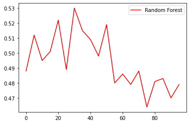

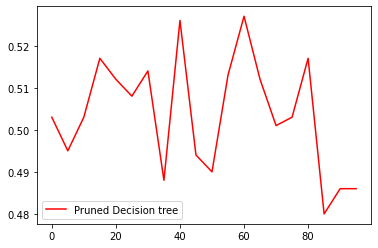

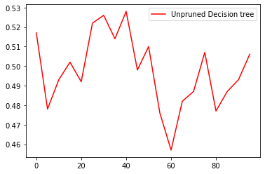

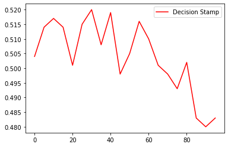

```python
# noise flipping the label

res1 = []
res2 = []
res3 = []
res4 = []
interval = (0, 100, 5)
for i in range(*interval):
    y_np = y
    for j in range(len(y_np)):
        getChoice = random.random()
        if getChoice < 0.05:
    # print(f"Flip index: {i}")
            y_np[j] = 1 - y_np[j]

    kfold = StratifiedKFold(n_splits=5, random_state=RANDOM_STATE, shuffle=True)
    score1 = []
    score2 = []
    score3 = []
    score4 = []
    for idx_train, idx_test in kfold.split(X_noise_multiply, y):
        X_train = X_noise_multiply[idx_train]
        X_test = X_noise_multiply[idx_test]
        y_train = y_np[idx_train]
        y_test = y_np[idx_test]
        # step 2: Random Forest
        score1.append(RandomForestClassifier(n_estimators=20, random_state = RANDOM_STATE, n_jobs=-1).fit(X_train, y_train).score(X_test, y_test))

        # step 3: Pruned Decision Tree, pruning is on validation set

        score2.append(DecisionTreeClassifier(max_depth = best_max_depth, min_samples_leaf=best_min_samples_leaf, min_samples_split=best_min_samples_split).fit(X_train, y_train).score(X_test, y_test))

        # step 4: Unpruned Decision Tree
        score3.append(DecisionTreeClassifier(random_state=RANDOM_STATE).fit(X_train, y_train).score(X_test, y_test))

        # step 5: Dicision stamp
        score4.append(DecisionTreeClassifier(max_depth=1, random_state=RANDOM_STATE).fit(X_train, y_train).score(X_test, y_test))
    res1.append(np.mean(score1))
    res2.append(np.mean(score2))
    res3.append(np.mean(score3))
    res4.append(np.mean(score4))

plt.plot(range(*interval), res1, color = "red", label = "Random Forest")
plt.legend()
plt.show()

plt.plot(range(*interval), res2, color = "red", label = "Pruned Decision tree")
plt.legend()
plt.show()

plt.plot(range(*interval), res3, color = "red", label = "Unpruned Decision tree")
plt.legend()
plt.show()

plt.plot(range(*interval), res4, color = "red", label = "Decision Stamp")
plt.legend()
plt.show()
```